# Lab 5 | Jon Lee

Lab 5 | BINF 6310 | Spring 2020 | Jon Lee

(1A) Plot the prior graph for a situation for a coin where the prior belief for p(head) is represented by the following R code:

```
dexp(x, rate = 5) / 0.9932621
```

for values of 0 ≤ x ≤ 1 and 0 otherwise. (We choose the denominator to make the Integral between 0 and 1 sum to 1).

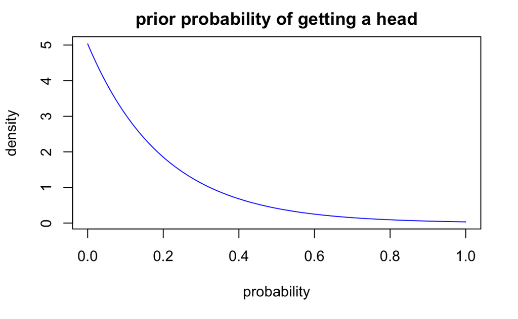

```r
probs <- seq(0, 1, 0.001)
prior <- dexp(probs, rate = 5)/0.9932621

#this <- dbeta(probs, prior, prior)
#plot(probs, this, xlim = c(0, 1), ylim = c(0, 2), type = "l")

plot(probs, prior, type = "l", xlab = "probability", ylab = "density", main = "prior probability of getting a head", col = "blue")
```

(1B) Calculate the posterior graph with both the Metropolis algorithm and grid approximation for a case with 14 heads and 10 tails (where x = prob(head)). Show the two methods roughly agree. Compare these to a plot with a posterior for new data of 14 heads and 10 tails with a prior with beta(40,40).

```r
#for piror p = dexp(x, rate = 5) / 0.9932621
#metropolis algorithm with addition of 14 heads and 10 tails
numIterations <- 20000

postDist_m1 <- vector(length = numIterations)
piO_m1 <- 0.5

for(i in 1:numIterations)
{
    pO_m1 <- (dexp(piO_m1, rate = 5)/0.9932621)*dbinom(14, 24, piO_m1)
    piN_m1 <- piO_m1+rnorm(1, 0, sd = 0.01)

    if(piN_m1 > 1)
        piN_m1 = 1;
    if(piN_m1 < 0)
        piN_m1 = 0;

    pN_m1 <- (dexp(piN_m1, rate = 5)/0.9932621)*dbinom(14, 24, piN_m1)
    ratio_m1 <- pN_m1/pO_m1

    if(ratio_m1 > 1 || ratio_m1 >= runif(1))
        piO_m1 = piN_m1;

    postDist_m1[i] = piO_m1
}

hist_m1 <- hist(postDist_m1, breaks = 200, plot = FALSE)

#grid approximation with addition of 14 heads and 10 tails
postDist_g1 <- vector()
Vals_g1 <- hist_m1$mids

i_g1 <- 1
sum_g1 <- 0

for(x in Vals_g1)
{
    #postDist_g1[i_g1] <- dbeta(p, 10, 10)*dbinom(14, 24, p)
    postDist_g1[i_g1] <- (dexp(x, rate = 5)/0.9932621)*dbinom(14, 24, x)
    sum_g1 <- sum_g1 + postDist_g1[i_g1]
    i_g1 <- i_g1 + 1
}

gridApprox_1 <- postDist_g1/sum_g1
```

```r
#grid approximation with addition of 14 heads and 10 tails; add 24 flips
postDist_g1 <- vector()
Vals_g1 <- hist_m1$mids

i_g1 <- 1
sum_g1 <- 0

for(x in Vals_g1)
{
    postDist_g1[i_g1] <- (dexp(x, rate = 5)/0.9932621)*dbinom(14, 24, x)
    sum_g1 <- sum_g1 + postDist_g1[i_g1]
    i_g1 <- i_g1 + 1
}

gridApprox_1 <- postDist_g1/sum_g1
```

```r
#plot metropolis
plot(hist_m1$mids, hist_m1$counts/numIterations, xlab = "probability", ylab = "density", pch = 20, ylim = c(0,0.04))
#plot grid approximation
lines(hist_m1$mids, gridApprox_1, col = "blue")
```

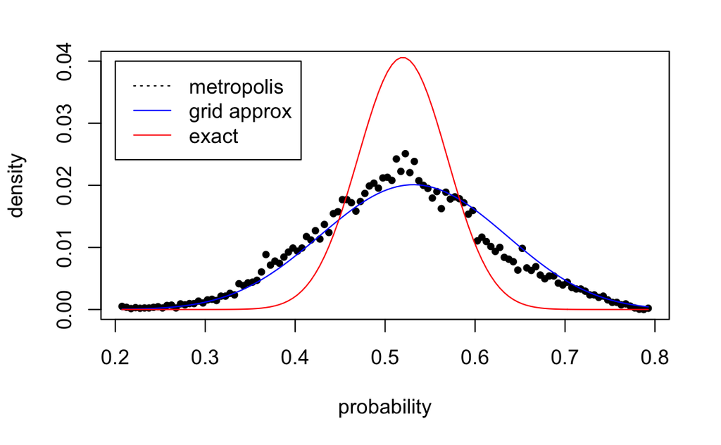

```r
#plot exact
exSum_1 <- sum(dbeta(hist_m1$mids, 54, 50))
lines(hist_m1$mids, (dbeta(hist_m1$mids, 54, 50))/exSum_1, col = "red")
#legned
legend(0.2, 0.04, legend = c("metropolis", "grid approx", "exact"), col = c("black", "blue", "red"), lty = c(3, 1, 1))
```

(So for the observation of 14 heads and 10 tails you will end up with a graph with three plots superimposed: (i) the Metropolis algorithm with an exp prior, (ii) grid approximation with an exp prior and (iii) exact analytical solution from a beta(40,40) prior make the plots different colors so you can visualize them…)

Answer: The metropolis and the grid approximation graphs are not as narrow as the exact analytical graph. Even thorugh they are more disperse, the center of all 3 do seem to line up.

```r
#for piror p = dexp(x, rate = 5) / 0.9932621
#metropolis algorithm with addition of 583 heads and 417 tails; add 1000 flips
postDist_m2 <- vector(length = numIterations)
piO_m2 <- 0.5

for(i in 1:numIterations)
{
    pO_m2 <- (dexp(piO_m2, rate = 5)/0.9932621)*dbinom(583, 1000, piO_m2)
    piN_m2 <- piO_m2+rnorm(1, 0, sd = 0.001)

    if(piN_m2 > 1)
        piN_m2 = 1;
    if(piN_m2 < 0)
        piN_m2 = 0;

    pN_m2 <- (dexp(piN_m2, rate = 5)/0.9932621)*dbinom(583, 1000, piN_m2)
    ratio_m2 <- pN_m2/pO_m2

    if(ratio_m2 > 1 || ratio_m2 >= runif(1))
        piO_m2 = piN_m2;

    postDist_m2[i] = piO_m2
}

hist_m2 <- hist(postDist_m2, breaks = 200, plot = FALSE)
```

```r
#grid approximation with addition of 583 heads and 417 tails; add 1000 flips
postDist_g2 <- vector()
Vals_g2 <- hist_m2$mids

i_g2 <- 1
sum_g2 <- 0

for(x in Vals_g2)
{
    postDist_g2[i_g2] <- (dexp(x, rate = 5)/0.9932621)*dbinom(583, 1000, x)
    sum_g2 <- sum_g2 + postDist_g2[i_g2]
    i_g2 <- i_g2 + 1
}

gridApprox_2 <- postDist_g2/sum_g2
```

```r
#plot metropolis
plot(hist_m2$mids, hist_m2$counts/numIterations, pch = 20, xlab = "probability", ylab = "density")
#plot grid approximation
lines(hist_m2$mids, gridApprox_2, col = "blue")
```

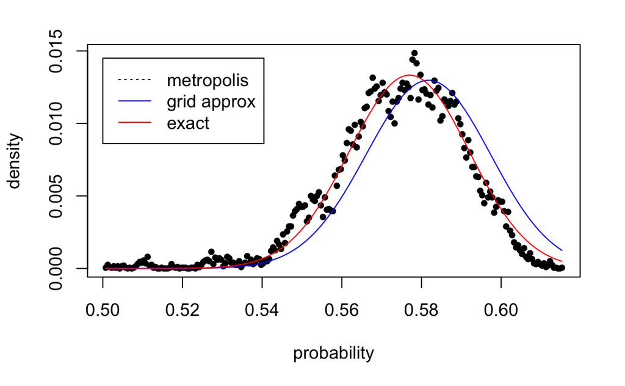

```r
#plot exact
exSum_2 <- sum(dbeta(hist_m2$mids, 623, 457))
lines(hist_m2$mids, (dbeta(hist_m2$mids, 623, 457))/exSum_2, col = "red")
#legend
legend(0.5, 0.0145, legend = c("metropolis", "grid approx", "exact"), col = c("black", "blue", "red"), lty = c(3, 1, 1))
```

HINTS: Watch your x-axis and y-axis scales here… Make sure all your curves are evaluated on the same set of x sequences. If someDistribution holds the results of your Metropolis walks, you can use…

```
myHist <- hist(someDist, breaks = 200, plot = FALSE)
```

to bin those results and then myHist$mids will hold the values for the x-axis for all your graphs.

Make sure the sum of each curve is equal to 1 when you graph them… So for the above histogram, you could plot…

```
plot(myHist$mids, myHist$counts/length(someDist), main = “Plot title here”)
```

You can add ylim() and xlim() as parameters to zoom in or zoom out as appropriate for that graph.

Then to add another distribution (that can be evaluated as a function ranging from 0 to 1) to the same graph:

```
aSum <- sum(nextDist(myHist$mids))
lines( myHist$mids, nextDist(myHist$mids)/aSum, col = "red")
```

(See lecture 7, slide 5 for an example of scaling…)